# Time Series

## Данные

Подключение библиотек:

```r
library(forecast)
library(tseries)
library(lmtest)
```

Загрузка данных:

```r
data <- read.csv("mean-monthly-air-temperature-deg.csv", sep=",", stringsAsFactors=F)
names(data)[1] <- "Date"
names(data)[2] <- "Value"
xname <- "Mean monthly air temperature (Deg. F) Nottingham Castle"
str(data)
```

```
## 'data.frame':    241 obs. of  2 variables:
##  $ Date : chr  "1920-01" "1920-02" "1920-03" "1920-04" ...
##  $ Value: num  40.6 40.8 44.4 46.7 54.1 58.5 57.7 56.4 54.3 50.5 ...
```

В конце данных — лишние строки:

```r
tail(data, n=10)
```

```
##                                                                  Date
## 232                                                           1939-04
## 233                                                           1939-05
## 234                                                           1939-06
## 235                                                           1939-07
## 236                                                           1939-08
## 237                                                           1939-09
## 238                                                           1939-10
## 239                                                           1939-11
## 240                                                           1939-12
## 241 Mean monthly air temperature (Deg. F) Nottingham Castle 1920-1939
##     Value
## 232  47.8
## 233  52.4
## 234  58.0
## 235  60.7
## 236  61.8
## 237  58.2
## 238  46.7
## 239  46.6
## 240  37.8
## 241    NA
```

Удалим их:

```r
nrows <- 1
data  <- data[-((dim(data)[1]-nrows+1) : dim(data)[1]),]
```

Настроим тип столбцов и сформируем объект типа ts для прогнозирования:

```r
data$Value <- as.numeric(data$Value)
data$Date <- as.Date(as.yearmon(data$Date, format="%Y-%m"))
tSeries <- ts(data = data$Value, start = as.numeric(c(format(data$Date[1], "%Y"), format(data$Date[1], "%m"))), freq = 12)
```

Здесь параметр start - год и месяц первого периода в данных, а freq = 12 указывает, что данные будут помесячные. Полученный ряд:

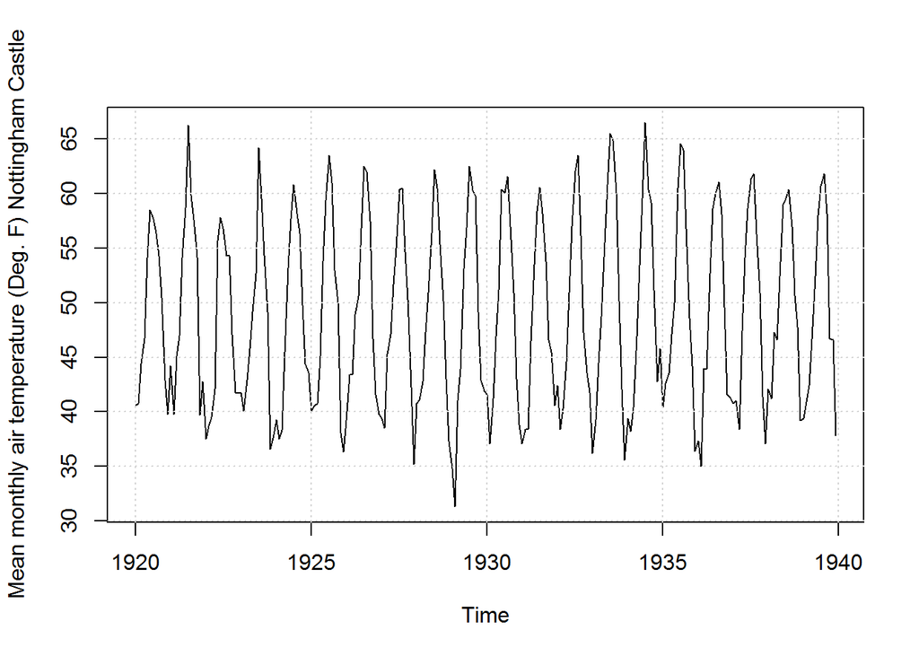

```r
plot(tSeries, type="l", ylab=xname)
grid()
```

Декомпозиция ряда:

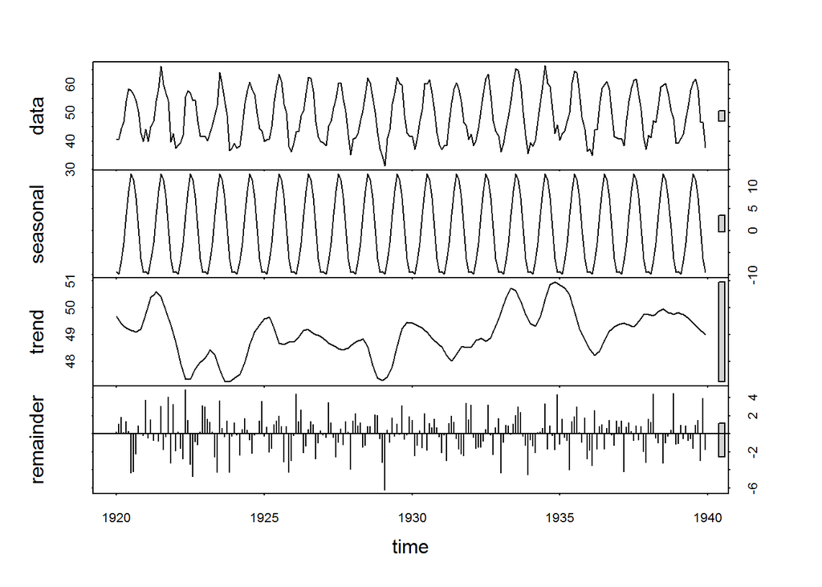

```r
plot(stl(tSeries, s.window="periodic"))
```

Выделим часть ряда для оценки качества прогнозов:

```r
trainend <- 1938
trainSeries <- window(tSeries,start=start(tSeries), end=trainend-.1)
testSeries <- window(tSeries, start=trainend)
D <- 24
```

D - горизонт прогнозирования, т.е. прогнозы мы будем строить на два года вперёд.

Подберём преобразование Бокса-Кокса:

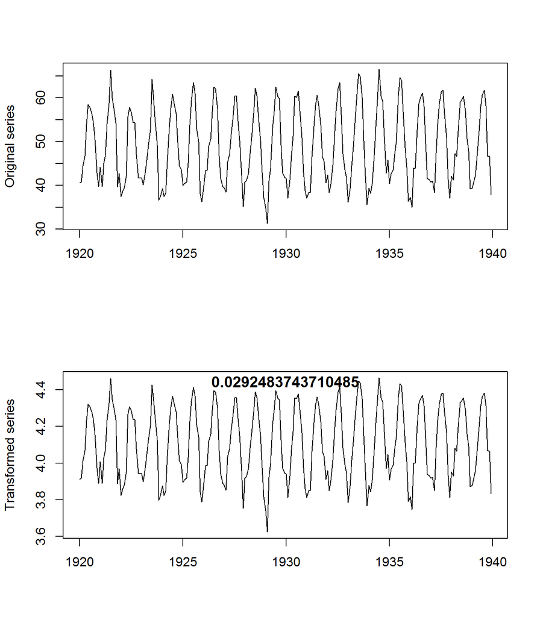

```r
par(mfrow=c(2,1))
plot(tSeries, ylab="Original series", xlab="")

LambdaOpt <- BoxCox.lambda(tSeries)
plot(BoxCox(tSeries, LambdaOpt), ylab="Transformed series", xlab="")
title(main=toString(LambdaOpt), line=-1)
```

## Прогноз ARIMA

### Прогноз ARIMA для исходного ряда ($\lambda=1$)

Подберём и настроим модель на полных данных:

```r
fit <- auto.arima(tSeries)
print(fit)
```

```
## Series: tSeries
## ARIMA(1,0,0)(2,0,0)[12] with non-zero mean
##
## Coefficients:
##          ar1    sar1    sar2  intercept
##       0.3375  0.3015  0.6449    49.5239
## s.e.  0.0645  0.0481  0.0485     2.2628
##
## sigma^2 estimated as 6.143:  log likelihood=-572.56
## AIC=1155.13   AICc=1155.38   BIC=1172.53
```

Настроив выбранную модель на обучающей выборке trainSeries, посчитаем её качество на тестовой testSeries:

```r
fitShort <- Arima(trainSeries, order=c(1,0,0), seasonal=c(2,0,0))
fc <- forecast(fitShort, h=D)
accuracy(fc,testSeries)
```

```
##                       ME     RMSE      MAE        MPE     MAPE      MASE
## Training set -0.02133903 2.496639 2.025588 -0.4231065 4.328727 0.7289388
## Test set      1.03891570 2.459512 1.801412  2.2066033 3.875675 0.6482658
##                     ACF1 Theil's U
## Training set -0.02005776        NA
## Test set     -0.04451615 0.5512554
```

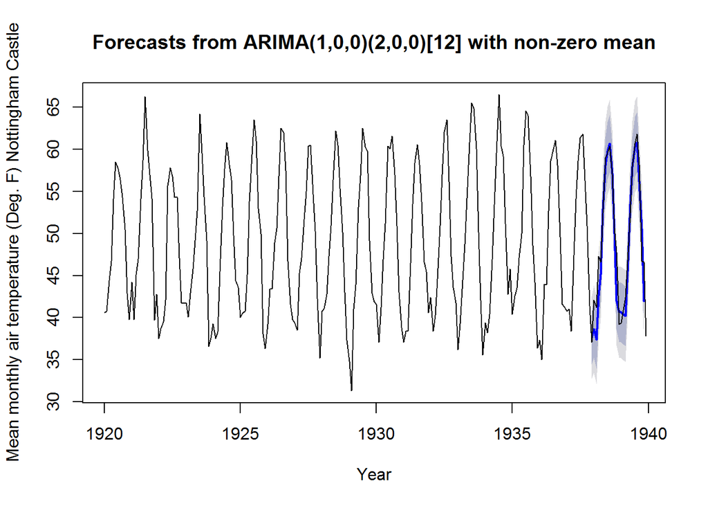

```r
plot(forecast(fitShort, h=D), ylab=xname, xlab="Year")
lines(tSeries, col="black")
```

Остатки:

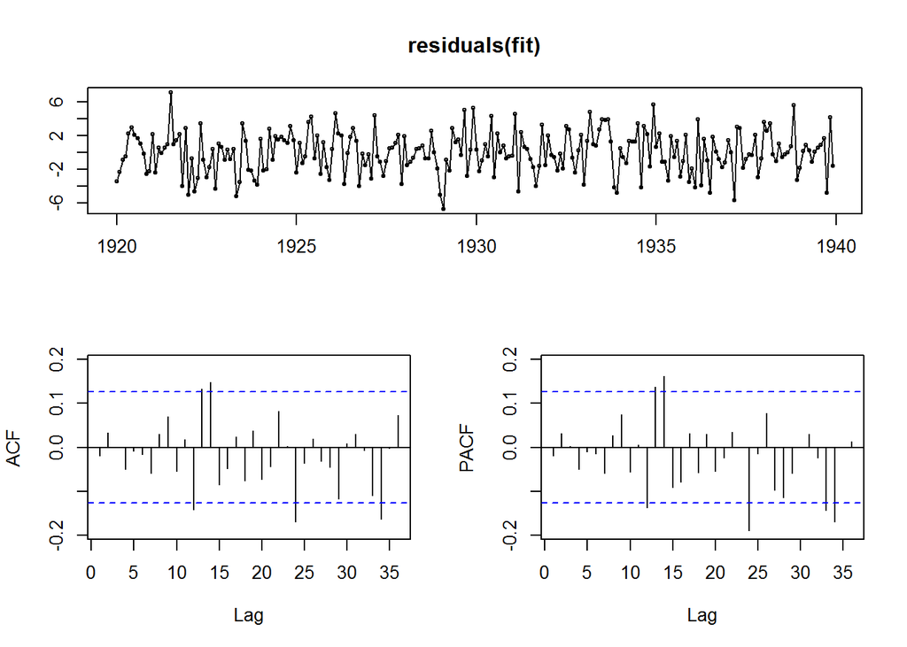

```r
tsdisplay(residuals(fit))
```

Критерий Льюнга-Бокса для них:

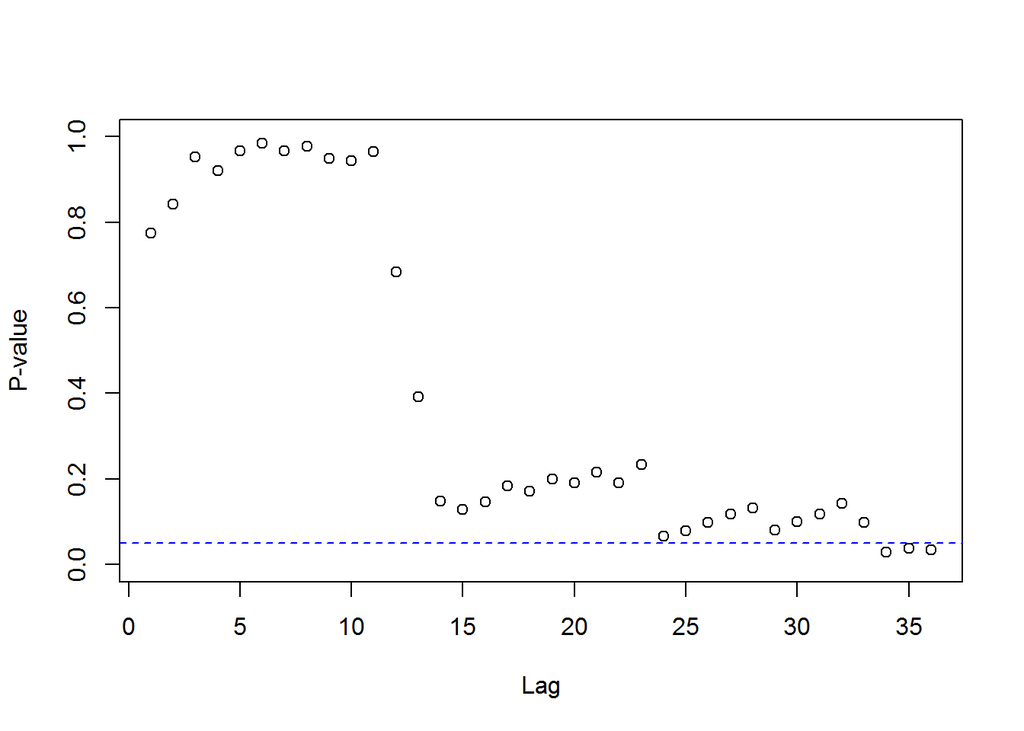

```r
p <- rep(0, 1, frequency(tSeries)*3)
for (i in 1:length(p)){
  p[i] <- Box.test(residuals(fit), lag=i, type = "Ljung-Box")$p.value
}
plot(p, xlab="Lag", ylab="P-value", ylim=c(0,1))
abline(h = 0.05, lty = 2, col = "blue")
```

Принимается гипотеза автокоррелированости.

Q-Q plot и гистограмма для остатков:

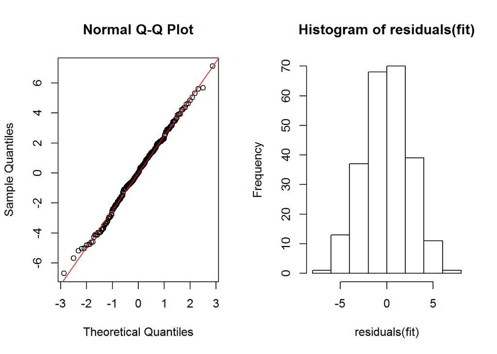

```r
par(mfrow=c(1,2))
qqnorm(residuals(fit))
qqline(residuals(fit), col="red")
hist(residuals(fit))
```

Распределение выглядит достаточно симметричным, явных отклонений от нормальности не видно. Убедимся при помощи критерия Шапиро-Уилка:

```r
shapiro.test(residuals(fit))
```

```
##
##  Shapiro-Wilk normality test
##
## data:  residuals(fit)
## W = 0.9966, p-value = 0.8921
```

Гипотеза нормальности не отвергается, поэтому для проверки несмещённости можно использовать критерий Стьюдента:

```r
t.test(residuals(fit))
```

```
##
##  One Sample t-test
##
## data:  residuals(fit)
## t = 0.0678, df = 239, p-value = 0.946
## alternative hypothesis: true mean is not equal to 0
## 95 percent confidence interval:
##  -0.3049599  0.3266870
## sample estimates:
##  mean of x
## 0.01086354
```

Гипотеза несмещённости не отвергается.

Гипотеза стационарности:

```r
kpss.test(residuals(fit))
```

```
##
##  KPSS Test for Level Stationarity
##
## data:  residuals(fit)
## KPSS Level = 0.0749, Truncation lag parameter = 3, p-value = 0.1
```

не отвергается критерием KPSS.

Гипотеза гомоскедастичности:

```r
bptest(residuals(fit) ~ c(1:length(residuals(fit))))
```

```
##
##  studentized Breusch-Pagan test
##
## data:  residuals(fit) ~ c(1:length(residuals(fit)))
## BP = 0.0031, df = 1, p-value = 0.9559
```

критерием Бройша-Пагана не отвергается.

Поскольку остатки автокоррелированы, для при построении предсказательных интервалов будем использовать метод симуляции.

Итоговый прогноз:

```r
f <- forecast(fit, h=D, bootstrap=TRUE)
print(f)
```

```
##          Point Forecast    Lo 80    Hi 80    Lo 95    Hi 95
## Jan 1940       41.48133 38.10266 44.59887 36.72292 46.12278
## Feb 1940       41.48696 38.08659 44.82772 36.38765 46.53837
## Mar 1940       45.91851 42.36763 49.40472 40.88257 51.16489
## Apr 1940       47.11059 43.61892 50.51601 41.91647 52.18151
## May 1940       52.24343 48.75903 55.79967 47.00822 57.38863
## Jun 1940       58.19035 54.62590 61.54840 53.24189 63.24991
## Jul 1940       59.39205 55.83502 62.81299 54.25472 64.53283
## Aug 1940       60.23989 56.65619 63.52699 55.16451 65.19162
## Sep 1940       56.96164 53.49624 60.34708 51.96728 62.07540
## Oct 1940       49.43088 45.88942 52.90475 44.25002 54.62017
## Nov 1940       47.53043 44.02332 50.91398 42.51720 52.59170
## Dec 1940       39.33045 35.68895 42.79680 34.06647 44.37514
## Jan 1941       40.56950 36.98058 44.17820 35.19043 45.94442
## Feb 1941       41.53860 37.94490 45.11930 36.06648 46.82150
## Mar 1941       43.84229 40.13223 47.34743 38.31720 49.27485
## Apr 1941       47.68439 44.14919 51.19268 42.41017 52.90583
## May 1941       52.19884 48.54454 55.77326 46.74892 57.69633
## Jun 1941       57.60370 53.97498 61.22603 52.16817 62.95387
## Jul 1941       59.70738 56.10492 63.18509 54.40440 65.02497
## Aug 1941       60.67246 56.99832 64.17976 55.25016 65.93575
## Sep 1941       57.36218 53.78283 60.96576 51.93549 62.85235
## Oct 1941       47.67462 44.16861 51.18767 42.46602 53.11312
## Nov 1941       47.03707 43.40977 50.65444 41.61347 52.48100
## Dec 1941       38.88904 35.21395 42.37980 33.28636 44.18725
```

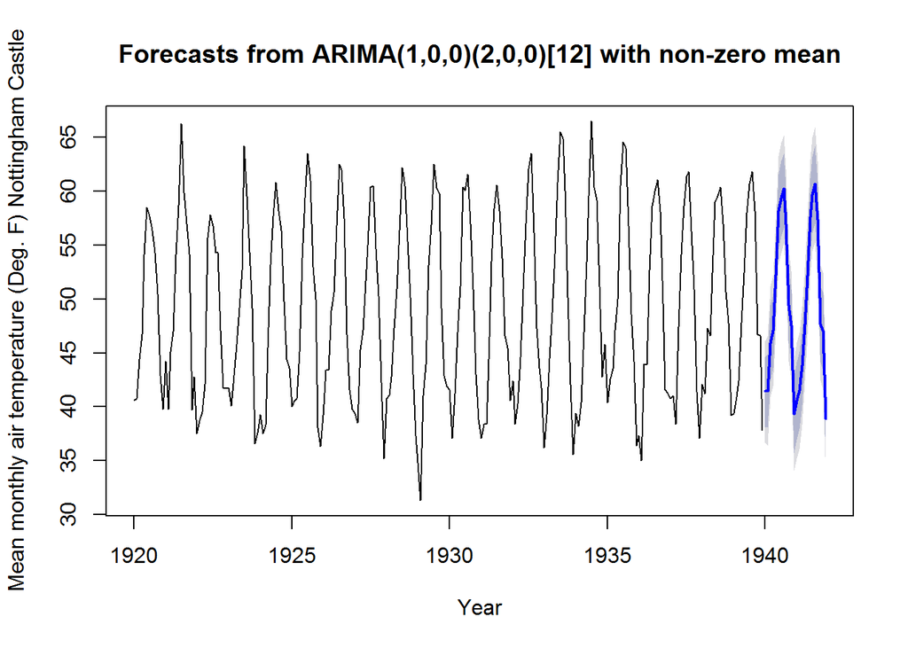

```r
plot(f, ylab=xname, xlab="Year")
```

### Прогноз ARIMA для преобразованного ряда ($\lambda=LambdaOpt$)

Подберём и настроим модель на полных данных:

```r
fitl <- auto.arima(tSeries,lambda=LambdaOpt)
print(fitl)
```

```
## Series: tSeries
## ARIMA(1,0,0)(2,0,0)[12] with non-zero mean
## Box Cox transformation: lambda= 0.02924837
##
## Coefficients:
##          ar1    sar1    sar2  intercept
##       0.3344  0.2870  0.6516     4.1196
## s.e.  0.0647  0.0471  0.0475     0.0508
##
## sigma^2 estimated as 0.003714:  log likelihood=317.42
## AIC=-624.83   AICc=-624.58   BIC=-607.43
```

Настроив выбранную модель на обучающей выборке trainSeries, посчитаем её качество на тестовой testSeries:

```r
fitShortl <- Arima(trainSeries, order=c(1,0,0), seasonal=c(2,0,0), lambda=LambdaOpt)
fcl <- forecast(fitShortl, h=D)
accuracy(fcl,testSeries)
```

```
##                      ME     RMSE      MAE        MPE     MAPE      MASE
## Training set 0.07509323 2.516442 2.040939 -0.2350039 4.340045 0.7344629
## Test set     1.15085455 2.501359 1.840144  2.4194156 3.955553 0.6622040
##                      ACF1 Theil's U
## Training set -0.003053319        NA
## Test set     -0.048847455 0.5604958
```

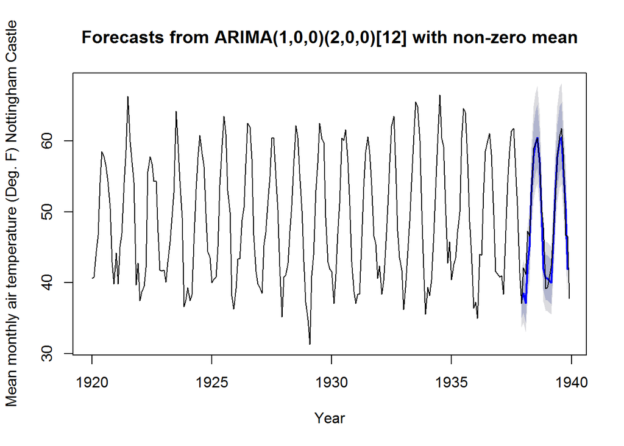

```r
plot(forecast(fitShortl, h=D), ylab=xname, xlab="Year")
lines(tSeries, col="black")
```

Остатки:

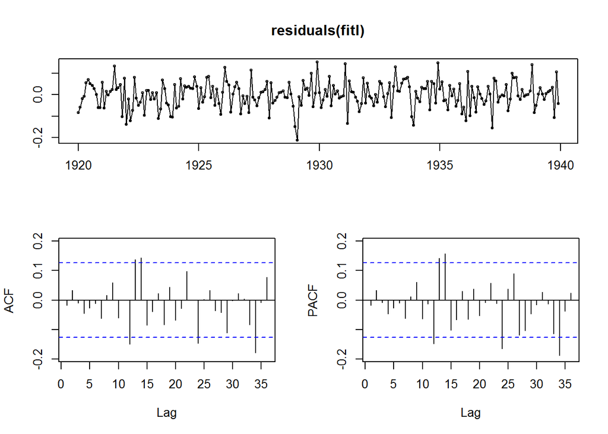

```r
tsdisplay(residuals(fitl))
```

Критерий Льюнга-Бокса для них:

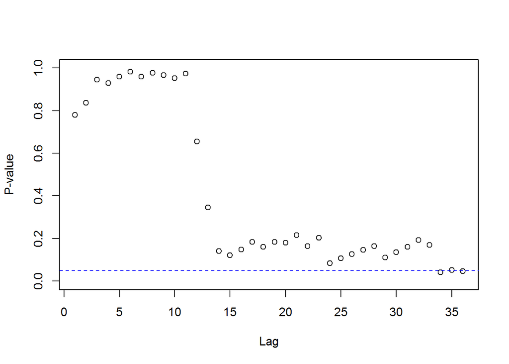

```r
p <- rep(0, 1, frequency(tSeries)*3)
for (i in 1:length(p)){
  p[i] <- Box.test(residuals(fitl), lag=i, type = "Ljung-Box")$p.value
}
plot(p, xlab="Lag", ylab="P-value", ylim=c(0,1))
abline(h = 0.05, lty = 2, col = "blue")
```

Принимаем гипотезу об автокоррелированости остатков.

Q-Q plot и гистограмма для остатков:

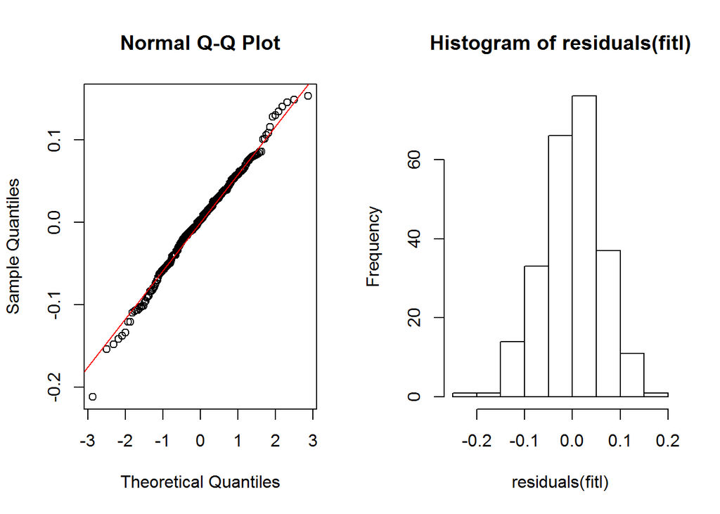

```r
par(mfrow=c(1,2))
qqnorm(residuals(fitl))
qqline(residuals(fitl), col="red")
hist(residuals(fitl))
```

Нормальность согласно критерия Шапиро-Уилкса не отвергается:

```r
shapiro.test(residuals(fitl))
```

```
##
##  Shapiro-Wilk normality test
##
## data:  residuals(fitl)
## W = 0.9932, p-value = 0.3457
```

поэтому для проверки несмещённости используем критерий Стьюдента:

```r
t.test(residuals(fitl))
```

```
##
##  One Sample t-test
##
## data:  residuals(fitl)
## t = 0.0074, df = 239, p-value = 0.9941
## alternative hypothesis: true mean is not equal to 0
## 95 percent confidence interval:
##  -0.007736646  0.007795213
## sample estimates:
##    mean of x
## 2.928366e-05
```

Гипотеза несмещённости не отвергается.

Гипотеза стационарности:

```r
kpss.test(residuals(fitl))
```

```
##
##  KPSS Test for Level Stationarity
##
## data:  residuals(fitl)
## KPSS Level = 0.0872, Truncation lag parameter = 3, p-value = 0.1
```

не отвергается критерием KPSS.

Гипотеза гомоскедастичности:

```r
bptest(residuals(fitl) ~ c(1:length(residuals(fitl))))
```

```
##
##  studentized Breusch-Pagan test
##
## data:  residuals(fitl) ~ c(1:length(residuals(fitl)))
## BP = 0.0164, df = 1, p-value = 0.898
```

критерием Бройша-Пагана не отвергается.

Однако остатки автокоррелированы, следовательно, при построении предсказательных интервалов предпочтительно пользоваться методом симуляции.

Итоговый прогноз:

```r
fl <- forecast(fitl, h=D,  bootstrap=TRUE)
print(fl)
```

```
##          Point Forecast    Lo 80    Hi 80    Lo 95    Hi 95
## Jan 1940       41.49350 38.54708 44.36432 36.93253 46.58614
## Feb 1940       41.48374 38.28610 44.48151 36.62582 46.67086
## Mar 1940       45.90957 42.59692 49.25928 40.82906 51.53575
## Apr 1940       47.07201 43.59333 50.55614 41.76424 52.96265
## May 1940       52.17521 48.37813 56.01034 46.22334 58.46100
## Jun 1940       58.03910 53.68423 62.31464 51.56780 65.02980
## Jul 1940       59.19218 54.77417 63.57891 52.30453 66.10515
## Aug 1940       60.01789 55.74956 64.36853 53.20723 67.04985
## Sep 1940       56.80619 52.60148 60.99106 50.34373 63.68938
## Oct 1940       49.40922 45.77588 52.90196 43.81639 55.63659
## Nov 1940       47.51871 43.88600 50.81580 41.95446 53.21573
## Dec 1940       39.32462 36.38108 42.23936 34.88823 44.10926
## Jan 1941       40.52491 37.60438 43.67113 35.83972 45.26490
## Feb 1941       41.52027 38.33376 44.71532 36.75440 46.51418
## Mar 1941       43.76137 40.42273 47.16475 38.65289 49.22644
## Apr 1941       47.65630 44.04282 51.31330 42.01501 53.45225
## May 1941       52.11391 48.26297 56.17136 45.98819 58.58841
## Jun 1941       57.40815 53.15395 61.85477 50.89059 64.60457
## Jul 1941       59.47143 54.82463 64.04443 52.42654 66.76518
## Aug 1941       60.41164 55.84533 65.09197 53.42740 67.88270
## Sep 1941       57.18361 52.83614 61.34691 50.39824 63.95894
## Oct 1941       47.59658 44.00379 51.34296 42.03113 53.61771
## Nov 1941       47.00055 43.47525 50.50796 41.68200 52.78196
## Dec 1941       38.84221 35.90718 41.78933 34.17320 43.75875
```

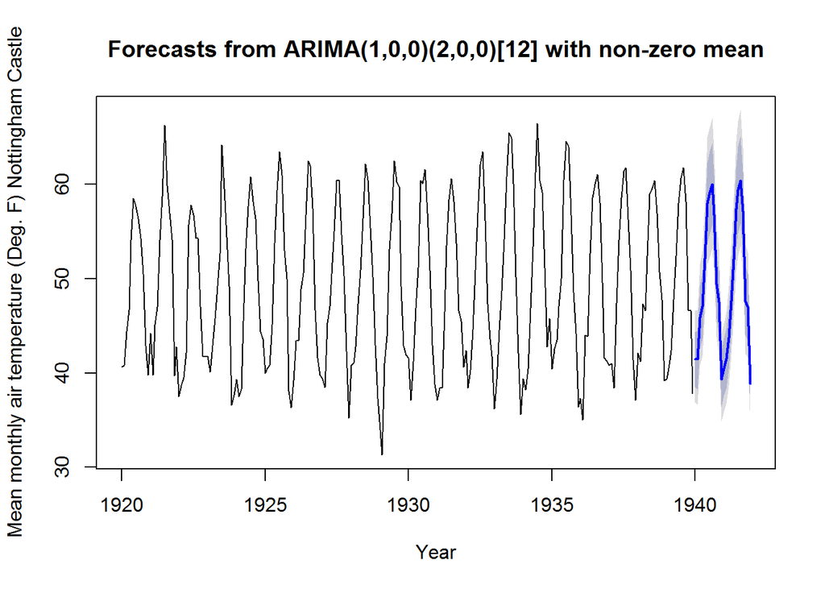

```r
plot(fl, ylab=xname, xlab="Year")
```

Проведём формальное сравнение качества двух прогнозов:

```r
res  <- fit$residuals
resl <- tSeries - InvBoxCox(BoxCox(tSeries, lambda=LambdaOpt) - fitl$residuals, lambda = LambdaOpt)
wilcox.test(abs(res) - abs(resl))
```

```
##
##  Wilcoxon signed rank test with continuity correction
##
## data:  abs(res) - abs(resl)
## V = 13530, p-value = 0.388
## alternative hypothesis: true location is not equal to 0
```

```r
dm.test(res, resl)
```

```
##
##  Diebold-Mariano Test
##
## data:  resresl
## DM = -1.6301, Forecast horizon = 1, Loss function power = 2,
## p-value = 0.1044
## alternative hypothesis: two.sided
```

Оба критерия показывают, что значимого различия между методами нет.

### Подбор параметров для ARIMA вручную

Учитывая, что остатки для ARIMA с автоматически подобранными параметрами, у нас получились автокоррелироваными, попробуем подобрать параметры вручную в окресности набора параметров, подобранных автроматически. В качестве меры используем RMSE. Также учитывая, что значимого различия между моделями, построенных на исходных и преобразованных данных, установить не удалось, будем считать, что $\lambda$=1.

```r
check_param <- function(i,j,k,r,s,t){
fitM <- Arima(trainSeries, order=c(i,j,k), seasonal=c(r,                                                 s,t))
fc <- forecast(fitM, h=D)
print(paste0("ARIMA(",i,",",j,",",k,")(",r,",",s,",",t,")"))
accuracy(fc,testSeries)[3:4]
}
check_param(1,0,0,2,0,0)
```

```
## [1] "ARIMA(1,0,0)(2,0,0)"
```

```
## [1] 2.496639 2.459512
```

```r
check_param(1,0,1,2,0,0)
```

```
## [1] "ARIMA(1,0,1)(2,0,0)"
```

```
## [1] 2.494908 2.466412
```

```r
check_param(1,0,0,2,1,1)
```

```
## [1] "ARIMA(1,0,0)(2,1,1)"
```

```
## [1] 2.176965 2.339064
```

```r
check_param(1,0,0,2,0,1)
```

```
## [1] "ARIMA(1,0,0)(2,0,1)"
```

```
## [1] 2.263214 2.252048
```

```r
check_param(1,0,0,2,1,0)
```

```
## [1] "ARIMA(1,0,0)(2,1,0)"
```

```
## [1] 2.322511 2.391931
```

```r
check_param(1,0,0,3,1,1)
```

```
## [1] "ARIMA(1,0,0)(3,1,1)"
```

```
## [1] 2.174403 2.331155
```

```r
check_param(1,0,0,3,1,2)
```

```
## [1] "ARIMA(1,0,0)(3,1,2)"
```

```
## [1] 2.152288 2.375766
```

С учетом того, что возможно переобучение (как на данных обучения, так и проверочных), оптимальной мне кажется модель ARIMA(1,0,0)(2,0,1) - с небольшим количеством параметров, у которой нет большой разницы в RMSE для данных обучения и проверки, и собственно RMSE небольшое относительно других значений.

Посмотрим на прогноз:

```r
fitM <- Arima(trainSeries, order=c(1,0,0), seasonal=c(2,0,1))
fc <- forecast(fitM, h=D)
accuracy(fc,testSeries)
```

```
##                    ME     RMSE      MAE        MPE     MAPE      MASE
## Training set 0.031389 2.263214 1.806195 -0.3035529 3.863447 0.6499868
## Test set     0.674956 2.252048 1.720487  1.6269660 3.604855 0.6191434
##                     ACF1 Theil's U
## Training set -0.03083982        NA
## Test set      0.14016646 0.4915597
```

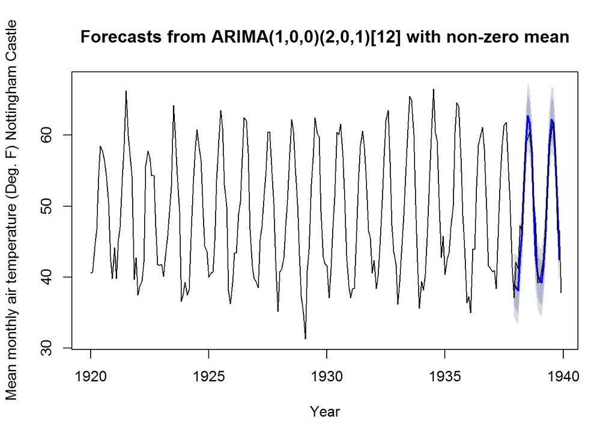

```r
plot(forecast(fitM, h=D), ylab=xname, xlab="Year")
lines(tSeries, col="black")
```

Остатки:

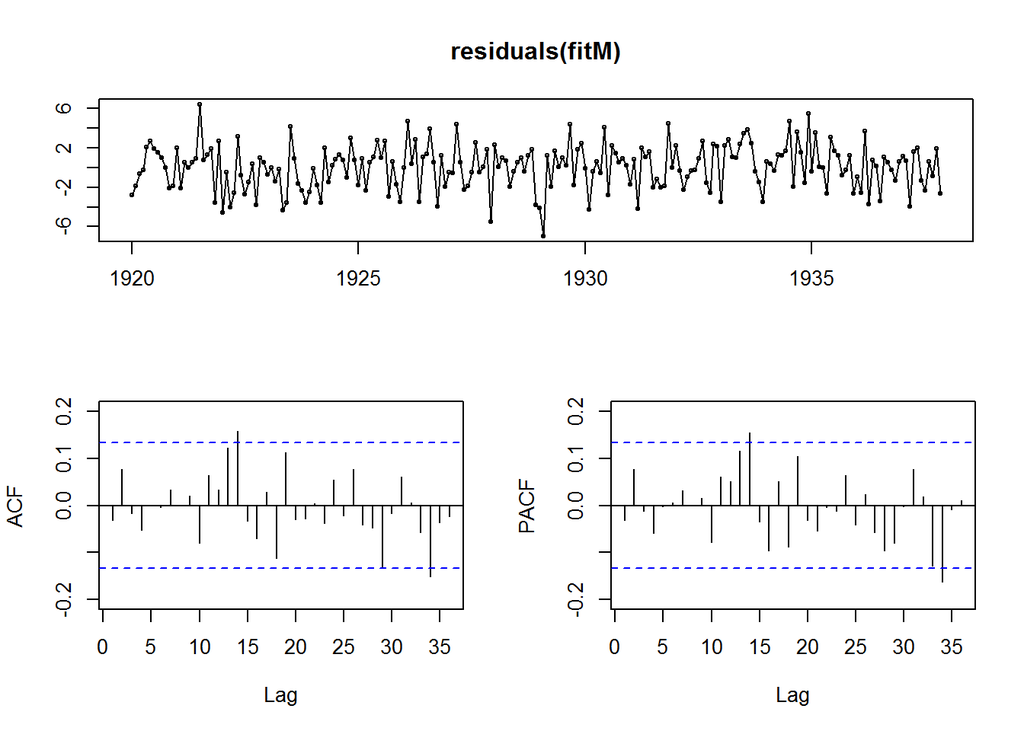

```r
tsdisplay(residuals(fitM))
```

Критерий Льюнга-Бокса для них:

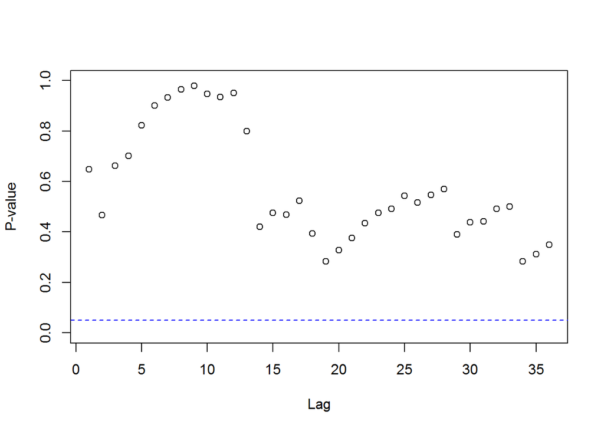

```r
p <- rep(0, 1, frequency(tSeries)*3)
for (i in 1:length(p)){
  p[i] <- Box.test(residuals(fitM), lag=i, type = "Ljung-Box")$p.value
}
plot(p, xlab="Lag", ylab="P-value", ylim=c(0,1))
abline(h = 0.05, lty = 2, col = "blue")
```

Как видим, нам удалось уменьшить степень автокоррелированости остатков.

Тот же график для 5-тикратного периода:

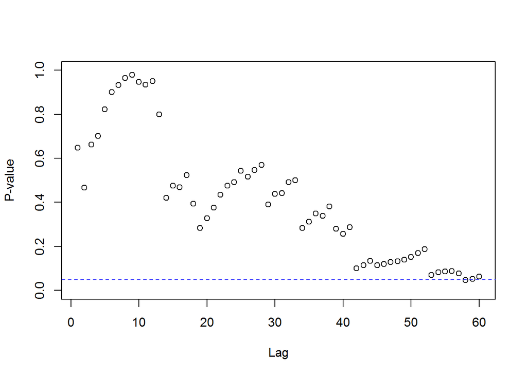

```r
p <- rep(0, 1, frequency(tSeries)*5)
for (i in 1:length(p)){
  p[i] <- Box.test(residuals(fitM), lag=i, type = "Ljung-Box")$p.value
}
plot(p, xlab="Lag", ylab="P-value", ylim=c(0,1))
abline(h = 0.05, lty = 2, col = "blue")
```

Q-Q plot и гистограмма для остатков:

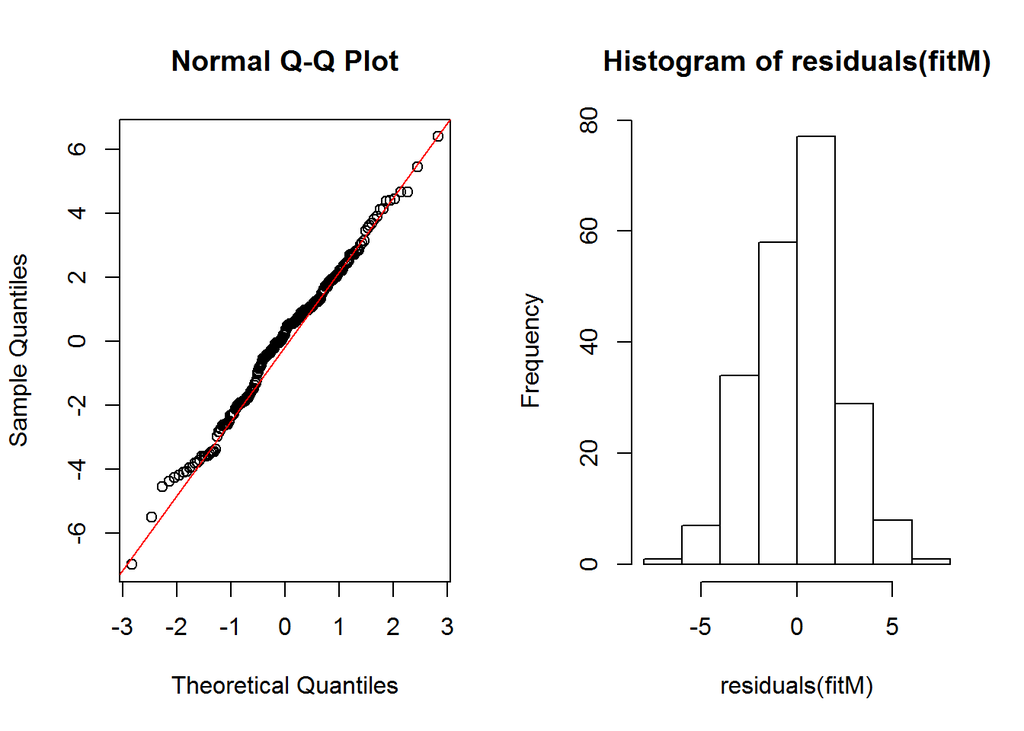

```r
par(mfrow=c(1,2))
qqnorm(residuals(fitM))
qqline(residuals(fitM), col="red")
hist(residuals(fitM))
```

Распределение выглядит достаточно симметричным, явных отклонений от нормальности не видно. Убедимся при помощи критерия Шапиро-Уилкса:

```r
shapiro.test(residuals(fitM))
```

```
##
##  Shapiro-Wilk normality test
##
## data:  residuals(fitM)
## W = 0.9924, p-value = 0.3308
```

Гипотеза нормальности не отвергается, поэтому для проверки несмещённости можно использовать критерий Стьюдента:

```r
t.test(residuals(fitM))
```

```
##
##  One Sample t-test
##
## data:  residuals(fitM)
## t = 0.2029, df = 214, p-value = 0.8394
## alternative hypothesis: true mean is not equal to 0
## 95 percent confidence interval:
##  -0.2735326  0.3363106
## sample estimates:
## mean of x
##  0.031389
```

Гипотеза несмещённости не отвергается.

Гипотеза стационарности:

```r
kpss.test(residuals(fitM))
```

```
##
##  KPSS Test for Level Stationarity
##
## data:  residuals(fitM)
## KPSS Level = 0.2383, Truncation lag parameter = 3, p-value = 0.1
```

не отвергается критерием KPSS.

Гипотеза гомоскедастичности:

```r
bptest(residuals(fitM) ~ c(1:length(residuals(fitM))))
```

```
##
##  studentized Breusch-Pagan test
##
## data:  residuals(fitM) ~ c(1:length(residuals(fitM)))
## BP = 0.1786, df = 1, p-value = 0.6726
```

критерием Бройша-Пагана не отвергается.

Поскольку остатки все же автокоррелированы, для при построении предсказательных интервалов будем использовать метод симуляции.

Итоговый прогноз:

```r
f <- forecast(fitM, h=D, bootstrap=TRUE)
print(f)
```

```
##          Point Forecast    Lo 80    Hi 80    Lo 95    Hi 95
## Dec 1937       38.89624 35.92794 41.62673 34.70371 43.31770
## Jan 1938       38.56921 35.36974 41.53956 33.95091 43.16611
## Feb 1938       38.15184 34.93615 41.18211 33.45860 42.93390
## Mar 1938       42.87540 39.68582 45.87799 38.10927 47.64352
## Apr 1938       45.95532 42.69210 48.96284 41.27504 50.58115
## May 1938       52.04656 48.79482 55.08039 47.25815 56.88946
## Jun 1938       58.96940 55.72309 61.86469 54.19841 63.56381
## Jul 1938       62.73093 59.41485 65.71490 58.00613 67.39968
## Aug 1938       61.73084 58.49170 64.79742 57.04249 66.35945
## Sep 1938       57.57397 54.31125 60.56631 52.85450 62.22335
## Oct 1938       49.29297 45.91700 52.18463 44.55795 53.95862
## Nov 1938       42.99023 39.75519 46.04987 38.41657 47.59287
## Dec 1938       40.26010 36.90959 43.27780 35.46402 44.82285
## Jan 1939       39.53683 36.28058 42.56774 34.81571 44.28379
## Feb 1939       39.20752 35.84952 42.28238 34.41838 43.85603
## Mar 1939       41.43235 38.19436 44.34908 36.71815 46.12250
## Apr 1939       46.45653 43.23067 49.52737 41.75149 51.16690
## May 1939       52.72126 49.48525 55.77993 48.04815 57.37430
## Jun 1939       58.80830 55.60073 61.83166 54.03669 63.51432
## Jul 1939       62.23422 58.93469 65.33105 57.61038 67.11040
## Aug 1939       61.70400 58.50679 64.75501 56.91543 66.37604
## Sep 1939       57.11628 53.85967 60.14056 52.41664 61.73823
## Oct 1939       49.82717 46.55245 52.81896 45.03102 54.51665
## Nov 1939       42.48480 39.29926 45.62149 37.85740 47.20291
```

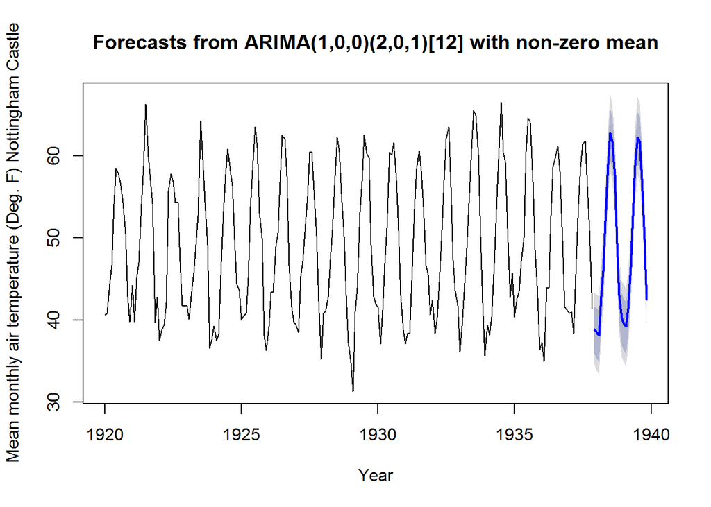

```r
plot(f, ylab=xname, xlab="Year")
```

Проведём формальное сравнение качества ARIMA(1,0,0)(2,0,0) и ARIMA(1,0,0)(2,0,1):

```r
res  <- fit$residuals
resM <- fitM$residuals
wilcox.test(abs(res) - abs(resM))
```

```
##
##  Wilcoxon signed rank test with continuity correction
##
## data:  abs(res) - abs(resM)
## V = 15483, p-value = 2.231e-05
## alternative hypothesis: true location is not equal to 0
```

```r
dm.test(res, resM)
```

```
##
##  Diebold-Mariano Test
##
## data:  resresM
## DM = 2.6006, Forecast horizon = 1, Loss function power = 2,
## p-value = 0.009886
## alternative hypothesis: two.sided
```

Оба критерия показывают, что различия между методами есть. Чтобы уточнить, какой лучше, повторим проверку гипотезы против односторонних альтернатив:

```r
dm.test(res, resM, alternative = "less")
```

```
##
##  Diebold-Mariano Test
##
## data:  resresM
## DM = 2.6006, Forecast horizon = 1, Loss function power = 2,
## p-value = 0.9951
## alternative hypothesis: less
```

```r
dm.test(res, resM, alternative = "greater")
```

```
##
##  Diebold-Mariano Test
##
## data:  resresM
## DM = 2.6006, Forecast horizon = 1, Loss function power = 2,
## p-value = 0.004943
## alternative hypothesis: greater
```

alternative = “greater” соответствует альтернативе о том, что метод 1 хуже метода 2. Именно против этой альтернативы нулевая гипотеза отвергается, следовательно, прогноз, построенный по модели ARIMA(1,0,0)(2,0,0), значимо хуже прогноза по ARIMA(1,0,0)(2,0,1). Таким образом, “руками” нам удалось заметно улучшить модель, подобранную компьтером, выполнив перебор по параметрам, исходя из предложенной модели как из исходной точки.